# Wrangle and Analyze WeRateDogs Data

by **Jamal Taghavimehr**

## Introduction

In this project I wrangled and analyzed data from a Twitter account called WeRateDogs. WeRateDogs is a Twitter account that rates people's dogs with a humorous comment about the dog. These ratings almost always have a denominator of 10. The numerators, though? Almost always greater than 10. 11/10, 12/10, 13/10, etc. Why? Because "they're good dogs Brent." WeRateDogs has over 4 million followers and has received international media coverage. The objective of this project was to clean the gathered data from twitter account and finally derive interesting conclusions from the results. Some questions that could be answered. Which dog breed has the highest rating? Which dog stage is the most frequent? What is the relationship betweet favourite and retweet counts vs dog rating?

## The Most Frequent Dog Breeds and Stages

Dog Breeds were identified using a neural network method and the results were obtained via downloading image predictions file programatically in Python. The most frequent dog breeds were Golden and Lablador Retrievers. These two breeds are very family friendly and very good for kids. No wonder why they are the most frequent in this Twitter account.

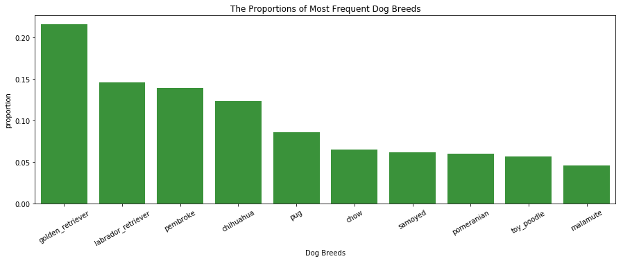

Moreover, dog stages were analyzed and although the majority of dogs were stage-less but the highest frequency belonged to doggo. There are not lots of puppers in our dataset.

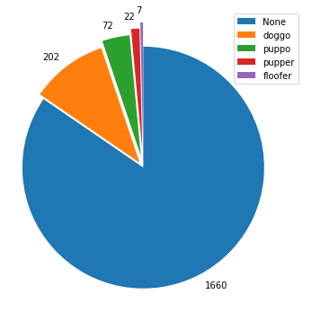

Let's have a look at the highest rated golden retreiver tweet. It is a three legged puppy with great determination to inspire everyone. Unfortunately it has passed away. This dog has every reason to be on top. His name was Ollie.

[figure not shown]

## Dog Rating Vs. Favourite and Retweet Counts

As I expected the number of favourites and retweets increase with dog rating. The tweets with higher rates tend to have more favourites and retweets.

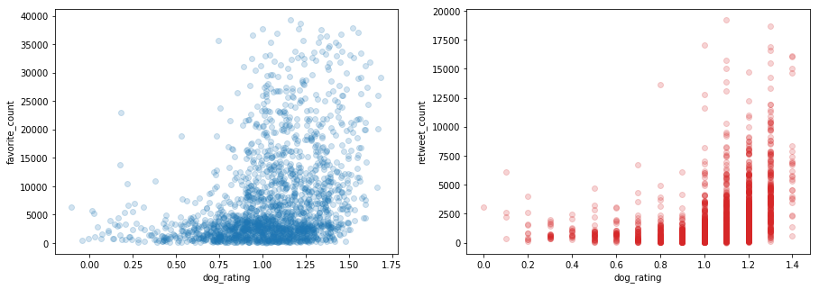

## Rating Vs. Breed and Stage

The most popular breed of pupper stage is samoyed, the most popular puppo is golden retreiver and pembroke, the most popular floofer is chow and samoyed, and the most popular doggo is pembroke.

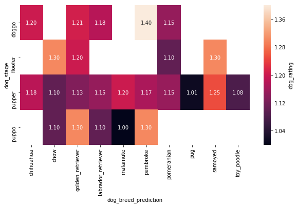

I'm interested to see one pembroke who is a doggo. Here it is:

[figure not shown]

## Conclusion

Dogs are funny and lovely. It is good to know more about them and analyze more data about them. The world of data is full of fun and surprises.